# Efecto Airbnb en Madrid

Este informe se ha generado automáticamente con R a partir del [script de Rmarkdown](https://github.com/montera34/airbnbeuskadi/tree/master/analisis/montera34/airbnb-informe-ciudad.Rmd) disponible en el [repositorio airbnbeuskadi](https://github.com/montera34/airbnbeuskadi/).

## Datos

- InsideAirbnb.com/MAdrid
- Fecha scraping: 2018-01-17

## Resumen

En **Madrid** hay publicados 16313 anuncios de Airbnb, que tienen capacidad para 53803 personas (accommodates).

De esos anuncios 0 han sido dados de alta (lo que supone un 0.0 % del municipio).

Estos anuncios (listings, en la terminología de Airbnb) han sido publicados por 9838 anfitriones.

## Anfitriones en Airbnb

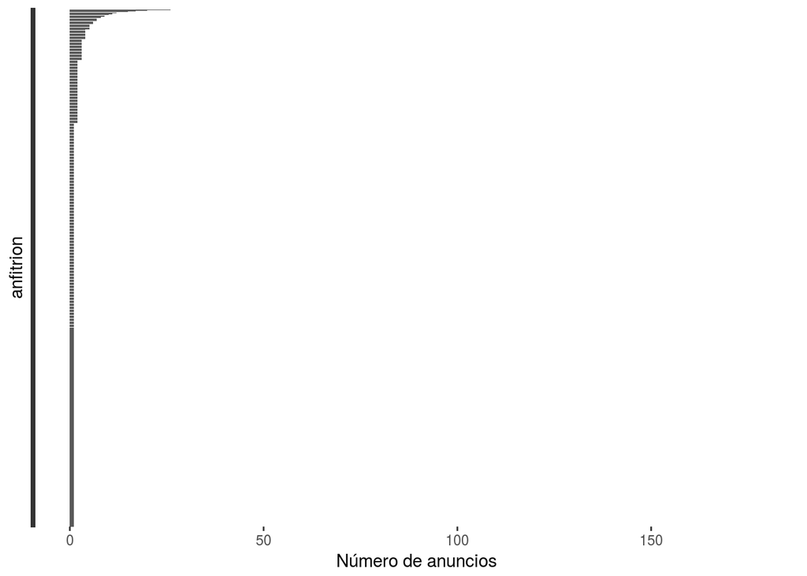

### Los anfitriones con más alojamientos

Los 20 anfitriones con más alojamientos (id)

| host_id | alojamientos |
| --- | --- |
| 102947901 | 179 |
| 3566146 | 101 |
| 54310958 | 79 |
| 117750911 | 76 |
| 27526991 | 64 |
| 100336740 | 61 |
| 99018982 | 59 |
| 1408525 | 54 |
| 5542111 | 49 |
| 28038703 | 49 |
| 37291567 | 44 |
| 85138877 | 41 |
| 138720343 | 41 |
| 30750005 | 38 |
| 32046323 | 38 |
| 89498753 | 37 |
| 60047857 | 33 |
| 157114944 | 30 |
| 596469 | 29 |
| 1650712 | 28 |

### Los anfitriones con más plazas

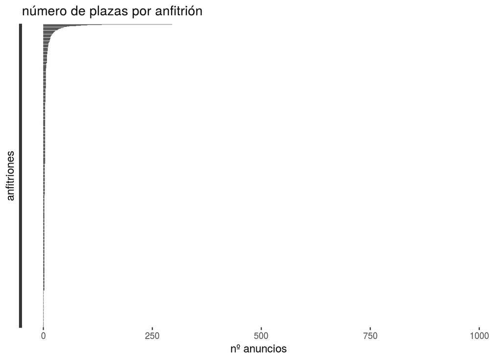

Los 10 primeros anfitriones (0.1% del total de anfitriones) con más plazas tienen 3456 plazas disponibles (que son el 6.4% del total de plazas).

Los 20 primeros anfitriones (0.2% del total de anfitriones) con más plazas tienen 5007 plazas disponibles (que son el 9.3% del total de plazas).

Los 50 primeros anfitriones (0.5% del total de anfitriones) con más plazas tienen 7831 plazas disponibles (que son el 14.6% del total de plazas).

Los 100 primeros anfitriones (1.0% del total de anfitriones) con más plazas tienen 10704 plazas disponibles (que son el 19.9% del total de plazas).

| host_id | plazas |
| --- | --- |
| 102947901 | 988 |
| 3566146 | 439 |
| 54310958 | 344 |
| 27526991 | 310 |
| 99018982 | 296 |
| 100336740 | 294 |
| 138720343 | 206 |
| 37291567 | 198 |
| 5542111 | 192 |
| 1408525 | 189 |
| 85138877 | 188 |
| 28038703 | 184 |
| 156279074 | 170 |
| 60047857 | 168 |
| 96147078 | 168 |
| 32046323 | 159 |
| 40877988 | 134 |
| 157114944 | 132 |
| 51564174 | 126 |
| 1718458 | 122 |
| 28786243 | 119 |
| 1732442 | 112 |
| 2516266 | 111 |
| 4190343 | 109 |
| 89498753 | 105 |
| 14472608 | 104 |
| 107335103 | 104 |
| 85271787 | 102 |
| 2864064 | 101 |
| 17499500 | 101 |